# Modelling Land-use Impacts on Biodiversity with the PREDICTS Database

Tim Newbold

2025-08-12

# Introduction

The PREDICTS database (Hudson et al. 2017) is a fully open-access database containing spatial comparisons of biodiversity in different land uses worldwide.

You can get started quickly by downloading the PREDICTS database from my website, but if you intend to use the database in your research, I would ask you please to download the database (freely) from the [Natural History Museum data portal](http://doi.org/10.5519/0066354), so that appropriate credit is given.

```r
webFile <- url("https://timnewbold.github.io/predicts_database.rds?dl=1")
predicts <- readRDS(webFile)
```

To work with the database, you should install a package that contains some basic data-manipulation functions:

```r
remotes::install_github("timnewbold/predicts-demo",subdir="predictsFunctions")
```

```r
library(predictsFunctions)
```

# Database Structure

The PREDICTS database has a hierarchical structure.

At the highest level, data are drawn from 480 published papers (*Sources*) comparing biodiversity in different land uses.

Each data Source consists of one or more *Studies*. Sometimes, a published paper will contain biodiversity samples collected using more than one fundamental approach. For example, a paper may contain data for different taxonomic groups that would not appropriately have been sampled using the same methods. In such cases, because data are not directly comparable if collected using different methods, data Sources were split into multiple Studies. Otherwise, each Source contained a single Study.

Each Study consists of data sampled in one or more spatial *Blocks*. A Study was divided into more than one Block if the sampling showed spatial structuring, to allow us to delimit spatial aggregations of Sites, and thus to account for spatial structuring later when modelling the data.

Each *Block* contains two or more *Sites*, which are the specific locations at which biodiversity was sampled.

Within each *Site*, there are a series of *Measurements* - of species abundance (2,692,493 records), species occurrence (557,616 records), or species richness (295 records) - for each of the sampled taxa.

Key fields in the PREDICTS database relating to the hierarchical structure of the database

| Field | Description |
| --- | --- |
| Source_ID | The published paper (*Source*) from which data were derived |
| Study_number | Within each *Source*, the *Study* identifier |
| Study_name | A text description to identify the *Study* |
| SS | An amalgamation of *Source* and *Study* IDs, so that each *Study* in the database is uniquely identifiable |
| Block | A text description of distinct spatial *Blocks*, blank where sites were not spatially clustered |
| SSB | An almagamation of the unique *Study* identifier, *SS*, and *Block*, so that each *Block* is uniquely identifiable |
| Site_number | Within each *Study*, the *Site* identifier |
| Site_name | A text description to identify the *Site* |
| SSBS | An almagamation of the unique *Block* identifier, *SSB*, and the *Site* number, so that each *Site* is uniquely identifiable |
| SSS | As for *SSBS*, but excluding the block identifier - not recommended, but can be used if you don’t want to account for spatial structure |
| Measurement | The recorded *Measurement* of species abundance, species occurrence, or species richness (see next section) |

# Key Sampling Information

Measurements in PREDICTS consist of three broad types: species abundance, species occurrence (i.e., presence or absence), or species richness (the number of species sampled). Within these categories, there are lots of different specific metrics. Some measures of diversity are inherently sensitive to sampling effort, which has important implications for processing the data (see below).

The different underlying *Studies* in PREDICTS consist of data sampled using a whole host of different methods, and with widely differing levels of sampling effort. When analysing the PREDICTS data, it is important that diversity *Measurements* are comparable within *Studies*, whereas differences among *Studies* are handled by the hierarchical design of the models (see below). Therefore, it is a requirement of the PREDICTS database that sampling *methods* are constant within studies. Nevertheless, for 18% of studies, sampling effort differs among the sampled sites.

Most of the original biodiversity sampling in the studies contained within the PREDICTS database took place between 2000 and 2013.

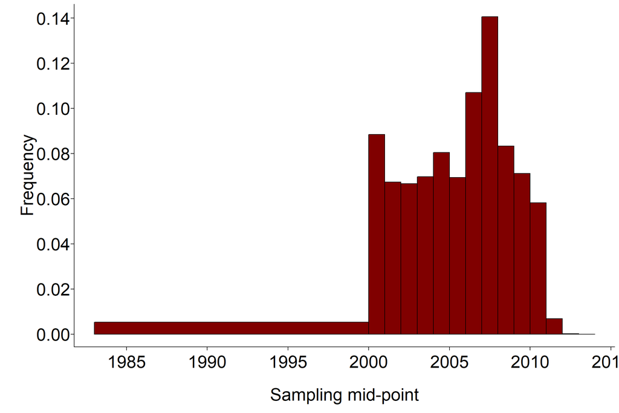

Distribution of mid-point sampling dates for the PREDICTS sites

Sampling at the sites in PREDICTS can span a range of different spatial extents. The maximum linear span of sampling for three-quarters of sites in the PREDICTS database falls between 3 and 502 metres.

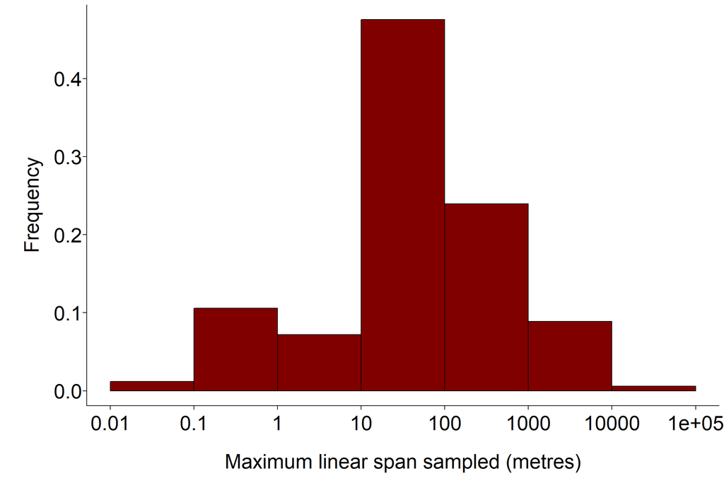

Distribution of maximum linear spans sampled at the PREDICTS sites

Key fields in the PREDICTS database describing biodiversity sampling

| Field | Description |
| --- | --- |
| Measurement | The recorded *Measurement* of species abundance, species occurrence, or species richness |
| Diversity_metric_type | Whether the recorded *Measurement* is of species abundance, species occurrence or species richness |
| Diversity_metric | The specific metric used for the taxon *Measurement* |
| Diversity_metric_unit | The units of the diversity metric |
| Diversity_metric_is_effort_sensitive | Whether the diversity metric is sensitive to sampling effort |
| Sampling_method | The method used to sample taxa |
| Sampling_effort | The sampling effort applied at the site |
| Rescaled_sampling_effort | Rescaled sampling effort, where the maximum within a study becomes 1, and everything else a fraction of the maximum |
| Sampling_effort_unit | The units of the sampling effort |
| Sample_start_earliest | The earliest date at which sampling may have begun |
| Sample_end_latest | The latest date at which sampling may have ended |
| Sample_date_resolution | The resolution of the sampling start and end dates (day, month or year) |
| Sample_midpoint | The mid-point between earliest sampling start and latest sampling end |
| Max_linear_extent_metres | The maximum linear span sampled at a given site |

# Spatial Information

The vast majority of sampled sites in the PREDICTS database (99.4%) are associated with geographical coordinates (longitude and latitude).

These geographical coordinates are then used to assign the site within various geographic schemes: biogeographic realms (Ladle and Whittaker 2011; Olson et al. 2001), biomes (Olson et al. 2001), ecoregions (Olson et al. 2001), UN regions and sub-regions ([United Nations, 1999](https://unstats.un.org/unsd/methodology/m49/)), biodiversity hotspots (Myers et al. 2000) and high-biodiversity wilderness areas (Brooks et al. 2006).

Key fields in the PREDICTS database describing the spatial location of biodiversity sampling

| Field | Description |
| --- | --- |
| Longitude | The longitude of the site at which sampling was undertaken |
| Latitude | The latitude of the site at which sampling was undertaken |
| Realm | Based on the coordinates, the location of the site within…biogeographic realms |
| Biome | …biomes |
| Ecoregion | …ecoregions |
| UN_region | …UN regions |
| UN_subregion | …UN sub-regions |
| Hotspot | …Biodiversity hotspots |
| Wilderness_area | …High-biodiversity wilderness areas |

# Human Pressure Information

The only information on human pressures that is endogenous to the PREDICTS database describes the land-use conditions at the sampled site, with the key variables representing land-use type and intensity of human land use.

In the majority of cases (at least 91.8%), land-use variables in the PREDICTS database were encoded using information given in the original source publications. Occasionally, the data entrant used Google Maps to infer the land-use type.

Land-use type is classified as one of: primary vegetation (apparently pristine habitat, with no record of prior destruction); secondary vegetation (habitat previously destroyed by human actions or extreme natural events, but now recovering towards its natural state); plantation forest (area used for growing woody crops); cropland (area used for growing herbaceous crops); pasture (area used for grazing livestock); urban (human settlements or areas of civic amenity). Secondary vegetation is also divided according to the stage of recovery toward its natural state: young, intermediate or mature. For full definitions, see (Hudson et al. 2017).

Land-use intensity is classified at one of three levels (minimal, light or intense), with the criteria for classification depending on land-use type (see (Hudson et al. 2017) for more details)

Key fields in the PREDICTS database describing human land-use pressures

| Field | Description |
| --- | --- |
| Habitat_as_described | The description of the habitat from the original source publication |
| Predominant_land_use | The land-use type, as classified by the data entrant |
| Source_for_predominant_land_use | Whether land-use type was classified based on information given in the original source publication or Google Maps |
| Use_intensity | Intensity of human land use, as classified by the data entrant |

# Taxonomic Information

The names of the sampled taxa, as given in the original source publications, are entered directly into the database. These names were passed through a taxonomic names resolver to attempt to correct any typographical errors from the original papers. Parsed names were then compared to the Catalogue of Life or manually checked, to try to find the accepted name for the species (successfully in the vast majority - 97.4 - of cases).

Key fields in the PREDICTS database relating to the taxonomy of sampled taxa

| Field | Description |
| --- | --- |
| Taxon_name_entered | The name of the sampled taxon, as given in the original source publication |
| Parsed_name | The name of the sampled taxon, after resolving any typos |
| Taxon | The accepted or provisionally accepted name for the species |
| Name_status | Whether the taxon name is accepted or provisionally accepted |
| Rank | The taxonomic rank of the accepted/provisionally accepted taxon name |
| Kingdom | For the accepted/provisionally accepted taxon name, the name of the …Kingdom |
| Phylum | …Phylum |
| Class | …Class |
| Order | …Order |
| Family | …Family |
| Genus | …Genus |
| Species | …Species |
| Best_guess_binomial | For as many sampled taxa as possible, the best guess of the Latin binomial name |
| Study_common_taxon | The taxonomic group within which all taxa sampled in a particular study belong |

# Data Pre-processing

```r
# Correct effort-sensitive abundance measures (assumes linear relationship between effort and recorded abundance)
predicts <- predictsFunctions::CorrectSamplingEffort(diversity = predicts)
```

```
## Correcting 8546 missing sampling effort values
## Rescaling sampling effort
## Correcting 2225047 values for sensitivity to sampling effort
```

Next, some samples in PREDICTS were entered such that a sampled ‘Site’ consisted of very finely divided samples. For example, samples may have been entered as individual traps. This is not in keeping with the strict definition of a ‘Site’ in the PREDICTS database. To get around this issue, we combine sites with identical coordinates, belonging to the same study and spatial block of sites, sampled on the same dates, sampled with the same methods and recorded using the same diversity metric, and situated within the same land-use type and human land-use intensity. This merging of sites is carried out by the *MergeSites* function in the *predictsFunctions* package (warning, this operation can take a few minutes to run, so you might want to go and make a cup of tea!):

```r
predicts <- predictsFunctions::MergeSites(diversity = predicts,silent = TRUE)
```

There are two main ways that you can now analyze the PREDICTS data:

1. Using the raw species-level data, modelling the presence/absence or abundance of individual species; or
2. Using site-level biodiversity summaries, such as species richness, total community abundance or other aggregate biodiversity measures

We are now ready to build some simple models using the PREDICTS database. For the modelling, we will use my *StatisticalModels* package, and we will use the *DHARMa* package for model diagnostics:

```r
library(StatisticalModels)
library(DHARMa)
```

# Basic Species-level Models

One way we can use the PREDICTS data is to build models based on the raw data for individual species.

So that the models run in a reasonably short amount of time, we will focus here on data for reptiles:

```r
reptiles <- droplevels(predicts[(predicts$Class=="Reptilia"),])
```

We will create a variable called “*Occur*” that represents the presence or absence of reptile species:

```r
# First, make sure that all records are of abundance or occurrence
reptiles <- reptiles[(reptiles$Diversity_metric_type %in% c("Abundance","Occurrence")),]

# Now, create the occurrence variable, where all values > 0 are treated as
# presence records
reptiles$Occur <- ifelse(reptiles$Measurement>0,1,0)
```

Before we build a model, we need to rearrange the land-use classification a bit. Any sites where the land-use type was entered as ‘Cannot decide’ need to be set as NA values. We will also group together secondary vegetation sites at all stages of recovery, since there are a relatively limited number of sites for reptiles.

```r
reptiles$LandUse <- dplyr::recode(reptiles$Predominant_land_use,
                                 'Primary vegetation' = 'Primary',
                                 'Young secondary vegetation' = 'Secondary',
                                 'Intermediate secondary vegetation' = 'Secondary',
                                 'Mature secondary vegetation' = 'Secondary',
                                 'Secondary vegetation (indeterminate age)' = "Secondary",
                                 'Plantation forest' = 'Plantation',
                                 'Cropland' = 'Cropland',
                                 'Pasture' = 'Pasture',
                                 'Urban' = 'Urban',
                                 'Cannot decide' = NA_character_)
```

Let’s try a very simple model fitting just land use. We will also build a null model for comparison.

```r
occMod1 <- StatisticalModels::GLMER(modelData = reptiles,responseVar = "Occur",
                               fitFamily = "binomial",fixedStruct = "LandUse",
                               randomStruct = "(1|SS)+(1|SSB)+(1|SSBS)+(1|Taxon_name_entered)",
                               saveVars = c("Longitude","Latitude"))

# To compare the models, they need to be fit to the same dataset
# Therefore, we first need to drop records with unknown land-use type
reptiles.with.lu <- reptiles[(!is.na(reptiles$LandUse)),]

occModNull <- StatisticalModels::GLMER(modelData = reptiles.with.lu,responseVar = "Occur",
                                  fitFamily = "binomial",fixedStruct = "1",
                                  randomStruct = "(1|SS)+(1|SSB)+(1|SSBS)+(1|Taxon_name_entered)",
                                  saveVars = c("Longitude","Latitude"))

print.LM(occMod1)
```

```
## A generalized linear model of family binomial
## Final call: Occur~LandUse+(1|SS)+(1|SSB)+(1|SSBS)+(1|Taxon_name_entered)
```

```r
summary.LM(occMod1)
```

```
## $family
## [1] "binomial"
##
## $call
## [1] "Occur~LandUse+(1|SS)+(1|SSB)+(1|SSBS)+(1|Taxon_name_entered)"
##
## $stats
## data frame with 0 columns and 0 rows
```

```r
AIC(occMod1$model,occModNull$model)
```

```
##                  df      AIC
## occMod1$model     9 16946.40
## occModNull$model  5 17007.73
```

```r
anova(occMod1$model,occModNull$model)
```

```
## Data: modelData
## Models:
## occModNull$model: Occur ~ 1 + (1 | SS) + (1 | SSB) + (1 | SSBS) + (1 | Taxon_name_entered)
## occMod1$model: Occur ~ LandUse + (1 | SS) + (1 | SSB) + (1 | SSBS) + (1 | Taxon_name_entered)
##                  npar   AIC   BIC  logLik -2*log(L)  Chisq Df Pr(>Chisq)
## occModNull$model    5 17008 17050 -8498.9     16998
## occMod1$model       9 16946 17022 -8464.2     16928 69.326  4  3.149e-14 ***
## ---
## Signif. codes:  0 '***' 0.001 '**' 0.01 '*' 0.05 '.' 0.1 ' ' 1
```

If we look at the pseudo R<sup>2</sup> values of the model, we can see that the random effects explain most of the variation in reptile species presence/absence, while land use explains 1.4%.

```r
StatisticalModels::R2GLMER(occMod1$model)
```

```
## $conditional
## [1] 0.7842631
##
## $marginal
## [1] 0.01386905
```

Plotting this model shows significant declines in the probability of occurrence of reptile species in secondary vegetation, plantation forests and pastures.

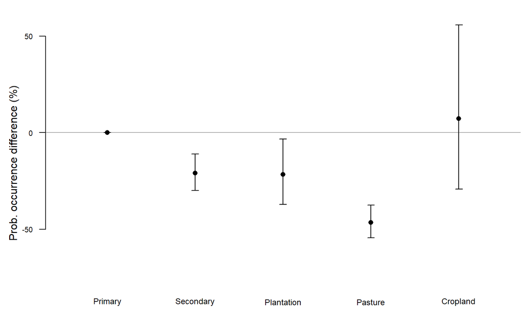

```r
PlotGLMERFactor(model = occMod1$model,data = occMod1$data,responseVar = "Prob. occurrence",logLink = "b",catEffects = "LandUse")
```

# Basic Assemblage-Level Models

To use the site-level approach, you need to use the *SiteMetrics* function to create a site-level data-frame. You can use the *extra.cols* argument to include non-standard columns from the original PREDICTS database into the site-level data-frame. For now, we will save the land-use type, the block and site-within-block unique identifiers, *SSB* and *SSBS* (which aren’t saved by default, and will be important in the modelling), and the Longitude and Latitude fields (as you will see, these will come in handy later for model checking):

```r
sites <- predictsFunctions::SiteMetrics(diversity = predicts,
                                           extra.cols = c("Longitude","Latitude",
                                                          "Predominant_land_use",
                                                          "SSB","SSBS"),
                                           srEstimators = NULL)
```

```
## Computing site metrics for 2906994 measurements
## The data contain 480 sources, 666 studies and 22678 sites
## Computing site-level values
## Computing total abundance
## Computing species richness
## Computing Simpson's diversity
## Assembling site-level values
```

As when we ran the species-level models, we need to rearrange the land-use classification. This time we have a lot of data available, so we will treat the secondary vegetation classes separately:

```r
sites$LandUse <- dplyr::recode(sites$Predominant_land_use,
                               'Primary vegetation'='Primary',
                               'Mature secondary vegetation'='Secondary_Mature',
                               'Intermediate secondary vegetation'='Secondary_Intermediate',
                               'Young secondary vegetation'='Secondary_Young',
                               'Plantation forest'='Plantation',
                               'Cropland'='Cropland',
                               'Pasture'='Pasture',
                               'Urban'='Urban',
                               'Secondary vegetation (indeterminate age)'=NA_character_,
                               'Cannot decide'=NA_character_)
```

We will start by running a very simple model of species richness as a function just of land use.

```r
richMod1 <- StatisticalModels::GLMER(modelData = sites,
                                     responseVar = "Species_richness",
                                     fitFamily = "poisson",
                                     fixedStruct = "LandUse",
                                     randomStruct = "(1|SS)+(1|SSB)",
                                     saveVars = c("Longitude","Latitude"))
```

If our species richness estimates conform to a true Poisson distribution, then the mean and variance of the values should be equal. Ecological count data are often over-dispersed, whereby the variance of the values is much greater than the mean. This seems very likely to be the case here:

```r
mean(sites$Species_richness)
```

```
## [1] 16.17568
```

```r
var(sites$Species_richness)
```

```
## [1] 575.4508
```

We can use the *GLMEROverdispersion* function to test the model, revealing substantial over-dispersion:

```r
StatisticalModels::GLMEROverdispersion(model = richMod1$model)
```

```
## $residDev
## [1] 42731.91
##
## $residDF
## [1] 20410
##
## $ratio
## [1] 2.093675
##
## $P.ChiSq
## [1] 0
```

One way to deal with the issue of over-dispersion in Poisson mixed-effects models is to include an observation-level random effect (i.e., a random effect with one group per data point). Here, this mean fitting site identity as a random effect:

```r
richMod2 <- StatisticalModels::GLMER(modelData = sites,
                                     responseVar = "Species_richness",
                                     fitFamily = "poisson",
                                     fixedStruct = "LandUse",
                                     randomStruct = "(1|SS)+(1|SSB)+(1|SSBS)",
                                     saveVars = c("Longitude","Latitude"))

print.LM(richMod2)
```

```
## A generalized linear model of family poisson
## Final call: Species_richness~LandUse+(1|SS)+(1|SSB)+(1|SSBS)
```

```r
summary.LM(richMod2)
```

```
## $family
## [1] "poisson"
##
## $call
## [1] "Species_richness~LandUse+(1|SS)+(1|SSB)+(1|SSBS)"
##
## $stats
## data frame with 0 columns and 0 rows
```

Testing for over-dispersion in the new model shows that we have dealt with the issue successfully:

```r
StatisticalModels::GLMEROverdispersion(model = richMod2$model)
```

```
## $residDev
## [1] 9972.64
##
## $residDF
## [1] 20409
##
## $ratio
## [1] 0.4886393
##
## $P.ChiSq
## [1] 1
```

Now that we have settled on a random-effects structure, we will create a null, intercept-only model with which to compare our model of the effect of land use:

```r
# To compare the models, they need to be fit to the same dataset
# Therefore, we first need to drop records with unknown land-use type
sites.with.lu <- sites[!is.na(sites$LandUse),]

richModNull <- StatisticalModels::GLMER(modelData = sites.with.lu,
                                     responseVar = "Species_richness",
                                     fitFamily = "poisson",
                                     fixedStruct = "1",
                                     randomStruct = "(1|SS)+(1|SSB)+(1|SSBS)",
                                     saveVars = c("Longitude","Latitude"))
```

Comparing the land-use and null models shows that land use has a strong association with species richness at the PREDICTS sites:

```r
AIC(richMod2$model,richModNull$model)
```

```
##                   df      AIC
## richMod2$model    11 118989.1
## richModNull$model  4 119572.6
```

```r
anova(richMod2$model,richModNull$model)
```

```
## Data: modelData
## Models:
## richModNull$model: Species_richness ~ 1 + (1 | SS) + (1 | SSB) + (1 | SSBS)
## richMod2$model: Species_richness ~ LandUse + (1 | SS) + (1 | SSB) + (1 | SSBS)
##                   npar    AIC    BIC logLik -2*log(L)  Chisq Df Pr(>Chisq)
## richModNull$model    4 119573 119604 -59782    119565
## richMod2$model      11 118989 119076 -59484    118967 597.46  7  < 2.2e-16 ***
## ---
## Signif. codes:  0 '***' 0.001 '**' 0.01 '*' 0.05 '.' 0.1 ' ' 1
```

Calculating the pseudo-R<sup>2</sup> values for the land-use model shows that land use alone only explains 0.5% of the variation in species richness, but that is unsurprising in such a heterogeneous database.

```r
R2GLMER(richMod2$model)
```

```
## $conditional
## [1] 0.6204898
##
## $marginal
## [1] 0.005113024
```

Plotting the modelled effects of land use on species richness shows a substantial reduction in species richness in more disturbed land uses:

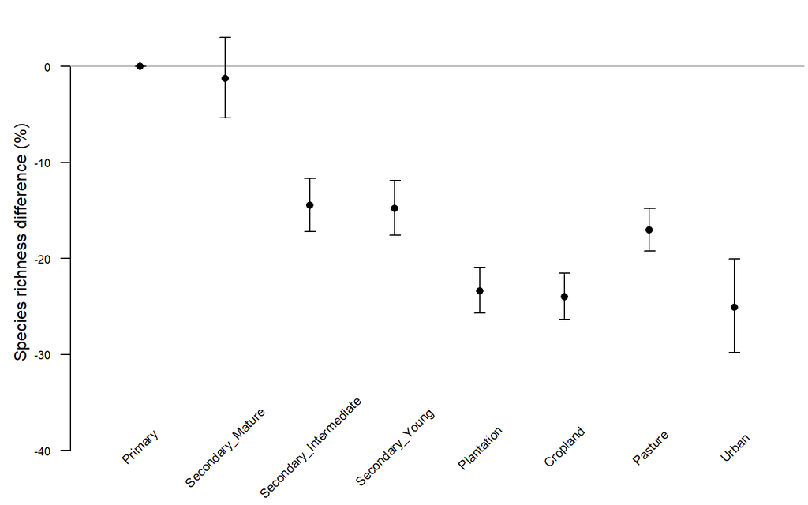

```r
PlotGLMERFactor(model = richMod2$model,data = richMod2$data,
                responseVar = "Species richness",logLink = "e",
                catEffects = "LandUse",xtext.srt = 45,
                order = c(1,4,3,2,5,7,6,8),
                params = list(mar = c(1.2, 3.5, 0.2, 0.2)))
```

With any analysis of spatial data, there is the possibility for spatial autocorrelation, meaning that data points cannot be assumed to be independent. Because of the hierarchical structure of the PREDICTS analyses, we tend to investigate spatial autocorrelation in the residuals associated with individual *Studies* in the original dataset. This can be done using the *SpatialAutocorrelationTest* function:

```r
sat <- StatisticalModels::SpatialAutocorrelationTest(richMod2,ranefGrouping = "SS")
```

[output not shown]

[output not shown]

[output not shown]

[output not shown]

[output not shown]

[output not shown]

[output not shown]

[output not shown]

[output not shown]

[output not shown]

[output not shown]

[output not shown]

[output not shown]

[output not shown]

[output not shown]

[output not shown]

[output not shown]

[output not shown]

[output not shown]

[output not shown]

[output not shown]

[output not shown]

[output not shown]

[output not shown]

[output not shown]

[output not shown]

[output not shown]

[output not shown]

[output not shown]

[output not shown]

[output not shown]

[output not shown]

[output not shown]

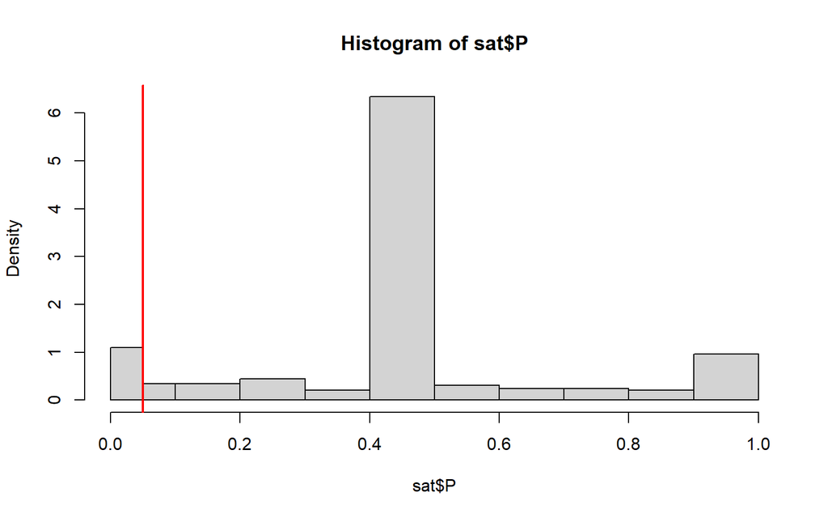

Distribution of P values from a series of tests for spatial autocorrelation in the residuals associated with underlying *Study*. P values < 0.05 indicate significant spatial autocorrelation

```r
hist(sat$P,breaks=c(0,0.05,0.1,0.2,0.3,0.4,0.5,0.6,0.7,0.8,0.9,1),freq=FALSE)
abline(v=0.05,lwd=2,col="#ff0000")
```

By chance, we would expect to see significant spatial autocorrelation in 5% of cases. Here the residuals associated with 5.5% of studies return a significant spatial autocorrelation test.

# References

Brooks, Thomas M., Russell A. Mittermeier, Gustavo A.B. da Fonseca, J. Gerlach, Michael Hoffmann, John F. Lamoreux, Cristina G. Mittermeier, John D. Pilgrim, and Ana S.L. Rodrigues. 2006. “Global Biodiversity Conservation Priorities.” *Science* 313: 58–61. https://doi.org/10.1126/science.1127609.

Hudson, Lawrence N., Tim Newbold, Sara Contu, Samantha L. L. Hill, Igor Lysenko, Adriana De Palma, Helen R. P. Phillips, et al. 2017. “The Database of the PREDICTS (Projecting Responses of Ecological Diversity In Changing Terrestrial Systems) Project.” *Ecology & Evolution* 7: 145–88. https://doi.org/10.1002/ece3.2579.

Ladle, Richard J., and Robert J. Whittaker. 2011. *Conservation Biogeography*. Wiley-Blackwell, Chichester, UK.

Myers, Norman, Russell A. Mittermeier, Cristina G. Mittermeier, Gustavo A.B. da Fonseca, and Jennifer Kent. 2000. “Biodiversity Hotspots for Conservation Priorities.” *Nature* 403: 853–58.

Olson, David M., Eric Dinerstein, Eric D. Wikramanayake, Neil D. Burgess, George V.N. Powell, Emma C. Underwood, Jennifer A. D’Amico, et al. 2001. “Terrestrial Ecoregions of the World: A New Map of Life on Earth.” *Bioscience* 51: 933–38. https://academic.oup.com/bioscience/article/51/11/933/227116.